# Non-Metric MDS

Chloe Jung

February 8, 2021

## PART 1:

### 1) Using isoMDS in R, run nonmetric (ordinal) MDS analyses of the data from Howe on similarity of crimes, in 1-4 dimensions. See the posted R example file for guidance.

```r
# load libraries
library(MASS)
# read in the data file
data.sim <- read.csv("CRIMES_PRX_clean.csv",header=TRUE)

# store the rownames/colnames into names
names <- data.sim[,1]

# convert to matrix
data.sim <- data.matrix(data.sim)

# remove the first column and make it as a row names
rownames(data.sim)<-names
data.sim <- data.sim[,-1]

# find maximum value
my_max=max(data.sim, na.rm=TRUE)
my_max
```

```
## [1] 186
```

```r
# dissimilarity matrix
data.dis = 190 - data.sim
data.dis
```

```
##              arson burglary childMoles distPeace DWI embezzlement kidnapping
## arson           NA       NA         NA        NA  NA           NA         NA
## burglary        57       NA         NA        NA  NA           NA         NA
## childMoles     109      104         NA        NA  NA           NA         NA
## distPeace       84       84        143        NA  NA           NA         NA
## DWI             96      121         99        91  NA           NA         NA
## embezzlement   102       65        131       126 130           NA         NA
## kidnapping      98       88         25       121  87           95         NA
## libel          113      124        149        85 122           71        126
## manslaughter    84       89         49       144  31          126         66
## murder-prem.    72       87         29       133  71          130         41
## perjury        100      101        138        88 117           55        114
## aggAssault      89       70         31        91  68          119         56
## rape           125       91          4       136  95          129         35
## rioting         75       15        127         8 109          115        129
## armRobbery      74       21         80       106  80          107         60
## sellDrugs       90      101        109       117  84           84        102
## shoplifting    110       12        141        79 136           41         85
## vandalism       28       52        121        45  94          110        116
##              libel manslaughter murder.prem. perjury aggAssault rape rioting
## arson           NA           NA           NA      NA         NA   NA      NA
## burglary        NA           NA           NA      NA         NA   NA      NA
## childMoles      NA           NA           NA      NA         NA   NA      NA
## distPeace       NA           NA           NA      NA         NA   NA      NA
## DWI             NA           NA           NA      NA         NA   NA      NA
## embezzlement    NA           NA           NA      NA         NA   NA      NA
## kidnapping      NA           NA           NA      NA         NA   NA      NA
## libel           NA           NA           NA      NA         NA   NA      NA
## manslaughter   125           NA           NA      NA         NA   NA      NA
## murder-prem.   126           23           NA      NA         NA   NA      NA
## perjury         26          130          119      NA         NA   NA      NA
## aggAssault      95           39           49     109         NA   NA      NA
## rape           127           38           20     128         15   NA      NA
## rioting         96          109          109     118         54  115      NA
## armRobbery     122           49           48     124         44   60      91
## sellDrugs      124          104           90     104         90  130     111
## shoplifting    113          142          131      71        123  141      78
## vandalism       90          130          113      88         81  112      32
##              armRobbery sellDrugs shoplifting vandalism
## arson                NA        NA          NA        NA
## burglary             NA        NA          NA        NA
## childMoles           NA        NA          NA        NA
## distPeace            NA        NA          NA        NA
## DWI                  NA        NA          NA        NA
## embezzlement         NA        NA          NA        NA
## kidnapping           NA        NA          NA        NA
## libel                NA        NA          NA        NA
## manslaughter         NA        NA          NA        NA
## murder-prem.         NA        NA          NA        NA
## perjury              NA        NA          NA        NA
## aggAssault           NA        NA          NA        NA
## rape                 NA        NA          NA        NA
## rioting              NA        NA          NA        NA
## armRobbery           NA        NA          NA        NA
## sellDrugs            91        NA          NA        NA
## shoplifting          86        95          NA        NA
## vandalism            87       104          69        NA
```

```r
# need to make the matrix symmetric
data.dis[is.na(data.dis)] <- 0
data.dis = (data.dis+t(data.dis))
data.dis
```

```
##              arson burglary childMoles distPeace DWI embezzlement kidnapping
## arson            0       57        109        84  96          102         98
## burglary        57        0        104        84 121           65         88
## childMoles     109      104          0       143  99          131         25
## distPeace       84       84        143         0  91          126        121
## DWI             96      121         99        91   0          130         87
## embezzlement   102       65        131       126 130            0         95
## kidnapping      98       88         25       121  87           95          0
## libel          113      124        149        85 122           71        126
## manslaughter    84       89         49       144  31          126         66
## murder-prem.    72       87         29       133  71          130         41
## perjury        100      101        138        88 117           55        114
## aggAssault      89       70         31        91  68          119         56
## rape           125       91          4       136  95          129         35
## rioting         75       15        127         8 109          115        129
## armRobbery      74       21         80       106  80          107         60
## sellDrugs       90      101        109       117  84           84        102
## shoplifting    110       12        141        79 136           41         85
## vandalism       28       52        121        45  94          110        116
##              libel manslaughter murder.prem. perjury aggAssault rape rioting
## arson          113           84           72     100         89  125      75
## burglary       124           89           87     101         70   91      15
## childMoles     149           49           29     138         31    4     127
## distPeace       85          144          133      88         91  136       8
## DWI            122           31           71     117         68   95     109
## embezzlement    71          126          130      55        119  129     115
## kidnapping     126           66           41     114         56   35     129
## libel            0          125          126      26         95  127      96
## manslaughter   125            0           23     130         39   38     109
## murder-prem.   126           23            0     119         49   20     109
## perjury         26          130          119       0        109  128     118
## aggAssault      95           39           49     109          0   15      54
## rape           127           38           20     128         15    0     115
## rioting         96          109          109     118         54  115       0
## armRobbery     122           49           48     124         44   60      91
## sellDrugs      124          104           90     104         90  130     111
## shoplifting    113          142          131      71        123  141      78
## vandalism       90          130          113      88         81  112      32
##              armRobbery sellDrugs shoplifting vandalism
## arson                74        90         110        28
## burglary             21       101          12        52
## childMoles           80       109         141       121
## distPeace           106       117          79        45
## DWI                  80        84         136        94
## embezzlement        107        84          41       110
## kidnapping           60       102          85       116
## libel               122       124         113        90
## manslaughter         49       104         142       130
## murder-prem.         48        90         131       113
## perjury             124       104          71        88
## aggAssault           44        90         123        81
## rape                 60       130         141       112
## rioting              91       111          78        32
## armRobbery            0        91          86        87
## sellDrugs            91         0          95       104
## shoplifting          86        95           0        69
## vandalism            87       104          69         0
```

```r
dimstress <- matrix(numeric(8),4,2)

#dimension 1
dimstress[1,1] <-1
dimstress[1,2] <- isoMDS(data.dis,k=1,trace=TRUE,p=2)$stress
#dimension 2
dimstress[2,1] <-2
dimstress[2,2] <- isoMDS(data.dis,k=2,trace=TRUE,p=2)$stress
#dimension 3
dimstress[3,1] <-3
dimstress[3,2] <- isoMDS(data.dis,k=3,trace=TRUE,p=2)$stress
#dimension 4
dimstress[4,1] <-4
dimstress[4,2] <- isoMDS(data.dis,k=4,trace=TRUE,p=2)$stress
dimstress
```

```
##      [,1]      [,2]
## [1,]    1 31.150235
## [2,]    2 23.275602
## [3,]    3 13.765114
## [4,]    4  7.967826
```

### 2) Prepare a plot of Stress vs. dimensionality for these four solutions. Judging from this plot, what do you think is the best dimensionality for these data? Why?

#### Answer: Dimensionality = 4 seems to be the best dimensionality for the data, as it has the lowest value of sterss.

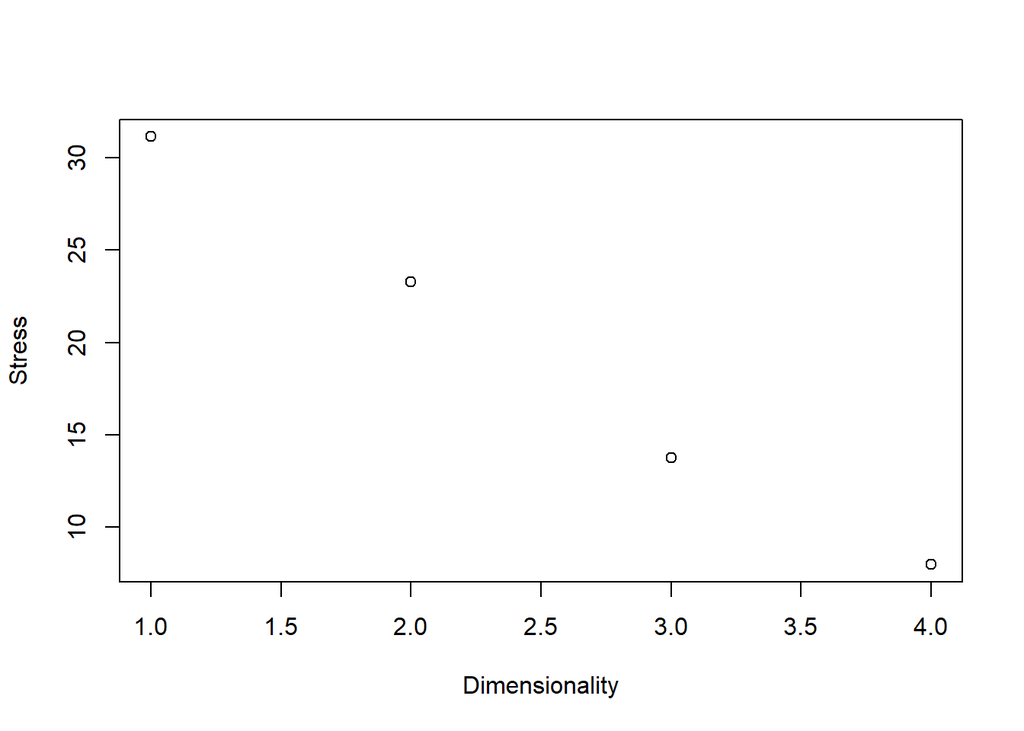

```r
plot(dimstress, xlab = "Dimensionality", ylab = "Stress")
```

### 3) Plot and label the 2-dim. configuration (regardless of your conclusions about dimensionality in part 2). Report your (subjective) interpretation for this solution.

```r
data.nmds <- isoMDS(data.dis,k=2,trace=TRUE,p=2)
data.nmds
```

```
## $points
##                    [,1]       [,2]
## arson         12.497502  25.669930
## burglary      18.851097  11.509221
## childMoles   -72.174245 -10.006542
## distPeace     57.701078  47.825630
## DWI          -29.775277  19.049963
## embezzlement  47.082531 -66.080971
## kidnapping   -41.086033 -34.229606
## libel         51.768722 -21.590004
## manslaughter -65.257807  -1.470285
## murder-prem. -58.547617  -2.079678
## perjury       55.263269 -42.707859
## aggAssault   -33.273592  20.610971
## rape         -65.026852  -4.922339
## rioting       36.012930  56.118319
## armRobbery   -26.158357   8.715099
## sellDrugs      6.077188 -22.633331
## shoplifting   63.090239 -23.782197
## vandalism     42.955224  40.003679
##
## $stress
## [1] 23.2756
```

```r
longdata <- data.nmds$points
longdata <- as.data.frame(longdata)
longdata$names <- rownames(data.nmds$points)
longdata
```

```
##                      V1         V2        names
## arson         12.497502  25.669930        arson
## burglary      18.851097  11.509221     burglary
## childMoles   -72.174245 -10.006542   childMoles
## distPeace     57.701078  47.825630    distPeace
## DWI          -29.775277  19.049963          DWI
## embezzlement  47.082531 -66.080971 embezzlement
## kidnapping   -41.086033 -34.229606   kidnapping
## libel         51.768722 -21.590004        libel
## manslaughter -65.257807  -1.470285 manslaughter
## murder-prem. -58.547617  -2.079678 murder-prem.
## perjury       55.263269 -42.707859      perjury
## aggAssault   -33.273592  20.610971   aggAssault
## rape         -65.026852  -4.922339         rape
## rioting       36.012930  56.118319      rioting
## armRobbery   -26.158357   8.715099   armRobbery
## sellDrugs      6.077188 -22.633331    sellDrugs
## shoplifting   63.090239 -23.782197  shoplifting
## vandalism     42.955224  40.003679    vandalism
```

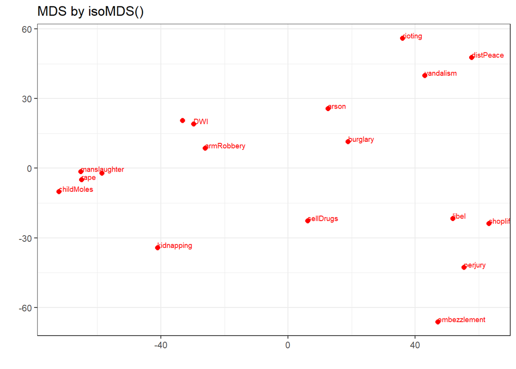

```r
library(ggplot2)
plot1 <- ggplot(longdata, aes(V1, V2, label=names)) +
  geom_point(colour="red", size=2) +
  geom_text(colour="red", check_overlap = TRUE, size=2.5,
            hjust = "left", vjust = "bottom", nudge_x = 0.02, nudge_y = 0) +
  labs(x="", y="", title="MDS by isoMDS()") + theme_bw()
plot1
```

## PART 2:

### 4) As an aid to interpretation: Using the 2-dimensional configuration you obtain from isoMDS, use a statistical package (R or SPSS) to regress the attribute of SERIOUSNESS into the solution space.

```r
#drop the third column, mnames
longdata = subset(longdata, select = -c(3) )
longdata
```

```
##                      V1         V2
## arson         12.497502  25.669930
## burglary      18.851097  11.509221
## childMoles   -72.174245 -10.006542
## distPeace     57.701078  47.825630
## DWI          -29.775277  19.049963
## embezzlement  47.082531 -66.080971
## kidnapping   -41.086033 -34.229606
## libel         51.768722 -21.590004
## manslaughter -65.257807  -1.470285
## murder-prem. -58.547617  -2.079678
## perjury       55.263269 -42.707859
## aggAssault   -33.273592  20.610971
## rape         -65.026852  -4.922339
## rioting       36.012930  56.118319
## armRobbery   -26.158357   8.715099
## sellDrugs      6.077188 -22.633331
## shoplifting   63.090239 -23.782197
## vandalism     42.955224  40.003679
```

```r
serious <- c(7.83,6.08,8.5,2.17,6.92,6.42,8.33,4.67,7.96,8.96,6.46,7.46,8.71,5.21,6.71,6.83,4.63,5.5)
serious <- as.data.frame(serious)

#bind "seriousness"
df <- cbind(longdata,serious)
df
```

```
##                      V1         V2 serious
## arson         12.497502  25.669930    7.83
## burglary      18.851097  11.509221    6.08
## childMoles   -72.174245 -10.006542    8.50
## distPeace     57.701078  47.825630    2.17
## DWI          -29.775277  19.049963    6.92
## embezzlement  47.082531 -66.080971    6.42
## kidnapping   -41.086033 -34.229606    8.33
## libel         51.768722 -21.590004    4.67
## manslaughter -65.257807  -1.470285    7.96
## murder-prem. -58.547617  -2.079678    8.96
## perjury       55.263269 -42.707859    6.46
## aggAssault   -33.273592  20.610971    7.46
## rape         -65.026852  -4.922339    8.71
## rioting       36.012930  56.118319    5.21
## armRobbery   -26.158357   8.715099    6.71
## sellDrugs      6.077188 -22.633331    6.83
## shoplifting   63.090239 -23.782197    4.63
## vandalism     42.955224  40.003679    5.50
```

```r
colnames(df) <- c("x1","x2","Y")
```

### Plot (by hand, or using the stat package) the regression line into a plot of the configuration space (one ignores the constant term in doing this).

```r
#Regression
fit<-lm(Y ~ x1 + x2, data=df)
summary(fit)
```

```
##
## Call:
## lm(formula = Y ~ x1 + x2, data = df)
##
## Residuals:
##      Min       1Q   Median       3Q      Max
## -1.99878 -0.48345  0.04895  0.44315  1.97272
##
## Coefficients:
##              Estimate Std. Error t value Pr(>|t|)
## (Intercept)  6.630556   0.207474  31.958 3.26e-15 ***
## x1          -0.029668   0.004377  -6.778 6.22e-06 ***
## x2          -0.015680   0.006611  -2.372   0.0315 *
## ---
## Signif. codes:  0 '***' 0.001 '**' 0.01 '*' 0.05 '.' 0.1 ' ' 1
##
## Residual standard error: 0.8802 on 15 degrees of freedom
## Multiple R-squared:  0.7746, Adjusted R-squared:  0.7446
## F-statistic: 25.78 on 2 and 15 DF,  p-value: 1.401e-05
```

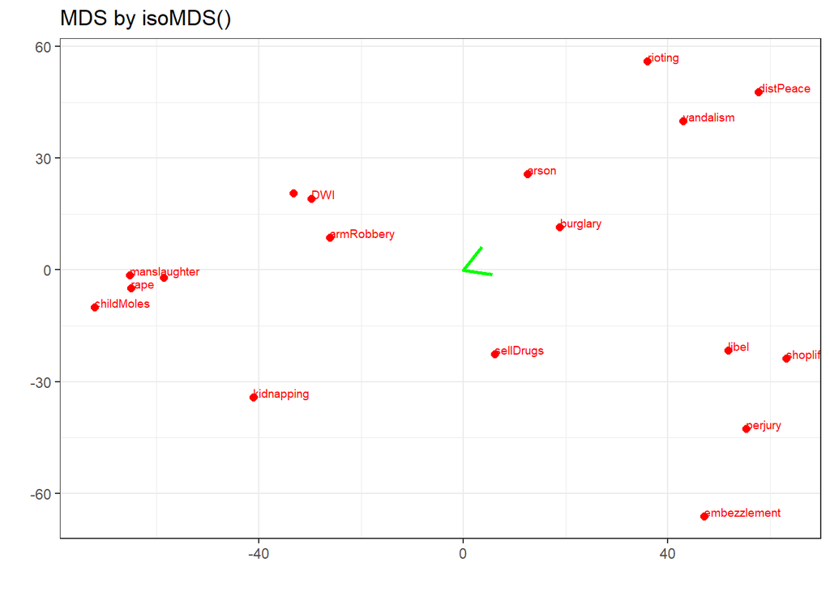

```r
#coefficient for x1
c1 <- fit$coefficients[2]

#coefficient for x2
c2 <- fit$coefficients[3]

plot2 <- plot1 +
   geom_segment(data=fit, mapping=aes(x=0, y=0, xend=c1, yend=c2), size=1, arrow=arrow(),color="green")
plot2
```